# Social_Survey_And_Lakers

Mia Fitzgerald

4/7/2026

### Combining Levels

```r
gss1 <- gss_cat %>%
  mutate(marital = fct_recode(marital,
"Pre-Marriage" = "Never married",
"Marriage" = "Married",
"Marriage" = "Separated",
"Post-Marriage" = "Divorced",
"Post-Marriage" = "Widowed",
"Missing" = "No answer"))

gss1 %>%
  count(marital) %>%
  kable()
```

| marital | n |
| --- | --- |
| Missing | 17 |
| Pre-Marriage | 5416 |
| Marriage | 10860 |
| Post-Marriage | 5190 |

I consolidated the specific marital statuses in the gss_cat dataset into four categories using fct_recode(). By grouping “Never married” as Pre-Marriage, “Married” and “Separated” as Marriage, and “Divorced” and “Widowed” as Post-Marriage. Finally, it generates a count of these new groups and displays them in a table. [^1]

### Proportion of Responses in Each Year

```r
gss2 <- gss1 %>%
  count(year, marital) %>%
  group_by(year) %>%
  mutate(prop = n/sum(n))

gss2 %>%
  kable()
```

| year | marital | n | prop |
| --- | --- | --- | --- |
| 2000 | Missing | 1 | 0.0003550 |
| 2000 | Pre-Marriage | 712 | 0.2527512 |
| 2000 | Marriage | 1390 | 0.4934327 |
| 2000 | Post-Marriage | 714 | 0.2534611 |
| 2002 | Pre-Marriage | 708 | 0.2560579 |
| 2002 | Marriage | 1365 | 0.4936709 |
| 2002 | Post-Marriage | 692 | 0.2502712 |
| 2004 | Pre-Marriage | 619 | 0.2201280 |
| 2004 | Marriage | 1574 | 0.5597440 |
| 2004 | Post-Marriage | 619 | 0.2201280 |
| 2006 | Missing | 6 | 0.0013304 |
| 2006 | Pre-Marriage | 1080 | 0.2394678 |
| 2006 | Marriage | 2326 | 0.5157428 |
| 2006 | Post-Marriage | 1098 | 0.2434590 |
| 2008 | Missing | 5 | 0.0024716 |
| 2008 | Pre-Marriage | 531 | 0.2624815 |
| 2008 | Marriage | 1042 | 0.5150766 |
| 2008 | Post-Marriage | 445 | 0.2199703 |
| 2010 | Missing | 1 | 0.0004892 |
| 2010 | Pre-Marriage | 565 | 0.2764188 |
| 2010 | Marriage | 956 | 0.4677104 |
| 2010 | Post-Marriage | 522 | 0.2553816 |
| 2012 | Pre-Marriage | 526 | 0.2664640 |
| 2012 | Marriage | 968 | 0.4903749 |
| 2012 | Post-Marriage | 480 | 0.2431611 |
| 2014 | Missing | 4 | 0.0015760 |
| 2014 | Pre-Marriage | 675 | 0.2659574 |
| 2014 | Marriage | 1239 | 0.4881797 |
| 2014 | Post-Marriage | 620 | 0.2442868 |

First, it counts how many people fall into each marital category for every year. Then, it groups the data by year so that it can calculate the portion of that specific year’s total. The final result is displayed as a formatted table. [^2]

### Status Reordered by Year

```r
gss3 <- gss2 %>%
  group_by(year, marital) %>%
  arrange(desc(year), desc(prop)) %>%
  ungroup()

gss3 %>%
  kable()
```

| year | marital | n | prop |
| --- | --- | --- | --- |
| 2014 | Marriage | 1239 | 0.4881797 |
| 2014 | Pre-Marriage | 675 | 0.2659574 |
| 2014 | Post-Marriage | 620 | 0.2442868 |
| 2014 | Missing | 4 | 0.0015760 |
| 2012 | Marriage | 968 | 0.4903749 |
| 2012 | Pre-Marriage | 526 | 0.2664640 |
| 2012 | Post-Marriage | 480 | 0.2431611 |
| 2010 | Marriage | 956 | 0.4677104 |
| 2010 | Pre-Marriage | 565 | 0.2764188 |
| 2010 | Post-Marriage | 522 | 0.2553816 |
| 2010 | Missing | 1 | 0.0004892 |
| 2008 | Marriage | 1042 | 0.5150766 |
| 2008 | Pre-Marriage | 531 | 0.2624815 |
| 2008 | Post-Marriage | 445 | 0.2199703 |
| 2008 | Missing | 5 | 0.0024716 |
| 2006 | Marriage | 2326 | 0.5157428 |
| 2006 | Post-Marriage | 1098 | 0.2434590 |
| 2006 | Pre-Marriage | 1080 | 0.2394678 |
| 2006 | Missing | 6 | 0.0013304 |
| 2004 | Marriage | 1574 | 0.5597440 |
| 2004 | Pre-Marriage | 619 | 0.2201280 |
| 2004 | Post-Marriage | 619 | 0.2201280 |
| 2002 | Marriage | 1365 | 0.4936709 |
| 2002 | Pre-Marriage | 708 | 0.2560579 |
| 2002 | Post-Marriage | 692 | 0.2502712 |
| 2000 | Marriage | 1390 | 0.4934327 |
| 2000 | Post-Marriage | 714 | 0.2534611 |
| 2000 | Pre-Marriage | 712 | 0.2527512 |
| 2000 | Missing | 1 | 0.0003550 |

I group the data so I can logically rank the information. The arrange() function puts the most recent years at the top and sorts status from the highest to the lowest. Making sure that for every year, you immediately see the most common marital status first. Finally, it removes the grouping and displays the results in a table. [^3]

### Proportion Versus Year

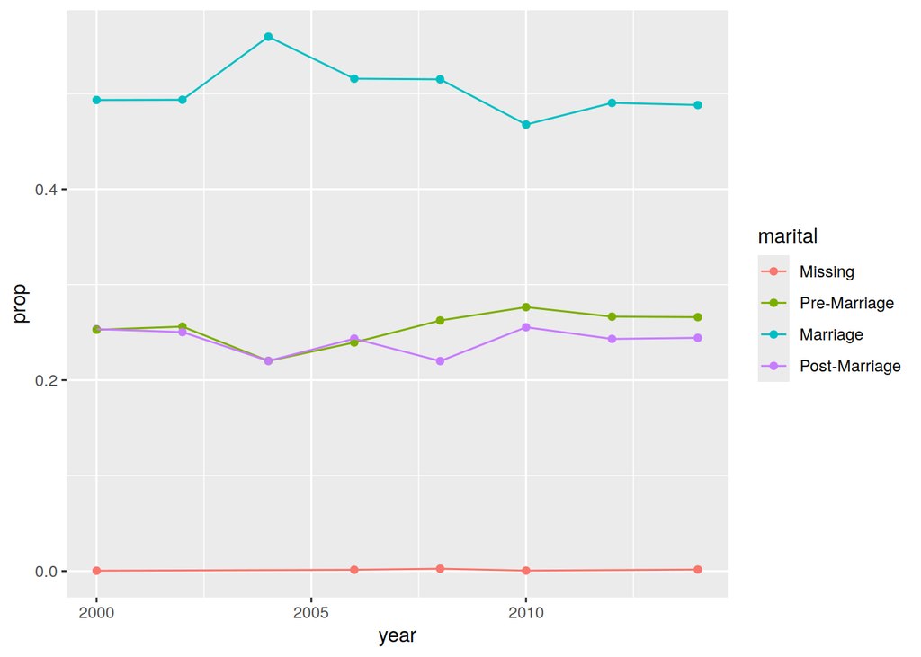

```r
ggplot(gss3, aes(x = year, y = prop, color = marital)) +
  geom_point() +
  geom_line()
```

Using the gss3 dataset, I created a line graph with data points to visualize how marital trends changed over time. The plot maps year to the x-axis and proportion to the y-axis, with each marital status represented by a unique color. [^4]

### Integer to Date Error

```r
lakers %>%
  mutate(new_date = make_date(date)) %>%
  select(date, new_date, time, player, result, etype, points) %>%
  head(n=6) %>%
  kable()
```

| date | new_date | time | player | result | etype | points |
| --- | --- | --- | --- | --- | --- | --- |
| 20081028 | -5877641-06-23 | 12:00 |  |  | jump ball | 0 |
| 20081028 | -5877641-06-23 | 11:39 | Pau Gasol | missed | shot | 0 |
| 20081028 | -5877641-06-23 | 11:37 | Vladimir Radmanovic |  | rebound | 0 |
| 20081028 | -5877641-06-23 | 11:25 | Derek Fisher | missed | shot | 0 |
| 20081028 | -5877641-06-23 | 11:23 | Pau Gasol |  | rebound | 0 |
| 20081028 | -5877641-06-23 | 11:22 | Pau Gasol | made | shot | 2 |

Because the date column in the lakers dataset is stored as an integer, so make_date() mistakenly tries to read that entire number as a year, resulting in invalid values. After, I select specific columns and display the first six rows in a formatted table. [^5]

### Subset of Dataset Including Parsed Dates

```r
lakers2 <- lakers %>%
  mutate(date2 = as.character(date)) %>%
  mutate(date2 = ymd(date2))

lakers2 %>%
  select(date, date2, team, etype, time, points) %>%
  head(6) %>%
  kable()
```

| date | date2 | team | etype | time | points |
| --- | --- | --- | --- | --- | --- |
| 20081028 | 2008-10-28 | OFF | jump ball | 12:00 | 0 |
| 20081028 | 2008-10-28 | LAL | shot | 11:39 | 0 |
| 20081028 | 2008-10-28 | LAL | rebound | 11:37 | 0 |
| 20081028 | 2008-10-28 | LAL | shot | 11:25 | 0 |
| 20081028 | 2008-10-28 | LAL | rebound | 11:23 | 0 |
| 20081028 | 2008-10-28 | LAL | shot | 11:22 | 2 |

I think it works better because it uses as.character() to turn the number into a string, so then I can use the ymd() function from the lubridate package to parse the date correctly. This creates a new column containing actual date objects. Then I select the relevant game details and display the first six rows in a clean table using kable(). [^6]

### Games Played on Different Days of the Week

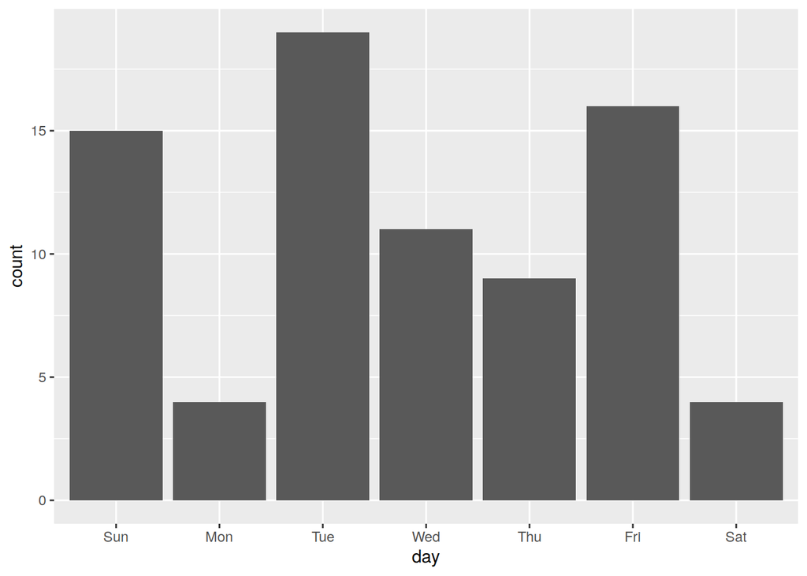

```r
lakers_bar <- lakers2 %>%
  distinct(date2) %>%
  mutate(day = wday(date2, label = TRUE, abbr = TRUE))

ggplot(lakers_bar, aes(day)) +
  geom_bar()
```

First, distinct() filters the dataset to keep only unique game dates. The mutate step then uses the wday() function to extract the day of the week from those dates, formatting them as labeled, abbreviated names. Finally, ggplot creates a bar chart that counts these instances, providing a visual summary of which days of the week were the busiest for the team. [^7]

[^1]: Question 1 complete
[^2]: Question 2 complete
[^3]: Question 3 complete
[^4]: Question 4 complete
[^5]: Question 5 complete
[^6]: Question 6 complete
[^7]: Question 7 complete